# **착륙 데이터 분석**

이 코드에서 사용된 딥러닝 모델은 분류 모델(DNN)과 회귀 모델(DNN)이다.

## 1. 착륙데이터 불러오기

여기서는 여러 CSV 파일에서 데이터를 읽어온다. 각 파일에서 cp_x, cp_y, altitude, x, y 열의 값을 추출하여 리스트에 저장하여 이후의 시각화 및 모델 훈련에 사용할 수 있게 준비한다. 아래의 landing_files 주석 처리를 통해 landing method 별로 검증이 가능하다. 주석은 마우스로 줄 드레그하고 ctrl + /

```python
import pandas as pd
import matplotlib.pyplot as plt
from mpl_toolkits.mplot3d import Axes3D

# 데이터 파일 경로 정의 , landing_files와 methods 주석처리해서 선택할 것
landing_files = [
    'C:/Users/henry/Desktop/landing_data/landing_data_aruco1.csv',
    'C:/Users/henry/Desktop/landing_data/landing_data_kalman1.csv',
    'C:/Users/henry/Desktop/landing_data/landing_data_yolo1.csv',
    'C:/Users/henry/Desktop/landing_data/landing_data_kalman_acc1.csv',

    'C:/Users/henry/Desktop/landing_data/landing_data_aruco2.csv',
    'C:/Users/henry/Desktop/landing_data/landing_data_kalman2.csv',
    'C:/Users/henry/Desktop/landing_data/landing_data_yolo2.csv',
    'C:/Users/henry/Desktop/landing_data/landing_data_kalman_acc2.csv',

    'C:/Users/henry/Desktop/landing_data/landing_data_aruco3.csv',
    'C:/Users/henry/Desktop/landing_data/landing_data_kalman3.csv',
    'C:/Users/henry/Desktop/landing_data/landing_data_yolo3.csv',
    'C:/Users/henry/Desktop/landing_data/landing_data_kalman_acc3.csv',
]

# methods = ['Aruco 1', 'Kalman 1', 'Yolo 1', 'Kalman acc 1']

# methods = ['Aruco 2', 'Kalman 2', 'Yolo 2', 'Kalman acc 2']

# methods = ['Aruco 3', 'Kalman 3', 'Yolo 3', 'Kalman acc 3']

methods = ['Aruco 1', 'Kalman 1', 'Yolo 1', 'Kalman acc 1', 'Aruco 2', 'Kalman 2', 'Yolo 2', 'Kalman acc 2', 'Aruco 3', 'Kalman 3', 'Yolo 3', 'Kalman acc 3']

# 데이터 저장을 위한 빈 리스트 초기화
cp_x_data, cp_y_data, altitude_data, x_data, y_data, z_data = [], [], [], [], [], []

# CSV 파일에서 데이터 읽기
for file in landing_files:
    data = pd.read_csv(file)
    cp_x_data.append(data['cp_x'])
    cp_y_data.append(data['cp_y'])
    altitude_data.append(data['altitude'])
    x_data.append(data['x'])
    y_data.append(data['y'])
    z_data.append(data['altitude'])
```

## 2. 2D 및 3D 데이터 시각화

### 2D 플롯: cp_x vs cp_y 비교

이 부분에서는 착륙 방법에 따라 cp_x와 cp_y 값을 산점도로 표시하여 각 방법의 분포를 시각적으로 비교한다.

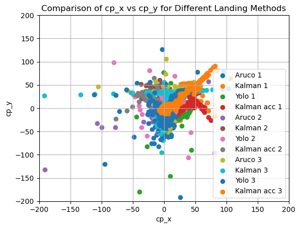

```python
plt.figure()
for i in range(len(cp_x_data)):
    plt.scatter(cp_x_data[i], cp_y_data[i], label=methods[i])
plt.xlim([-200, 200])
plt.ylim([-200, 200])
plt.xlabel('cp_x')
plt.ylabel('cp_y')
plt.title('Comparison of cp_x vs cp_y for Different Landing Methods')
plt.legend()
plt.grid(True)
plt.show()
```

### 3D 플롯: 비행 경로 비교

여기서는 x, y, altitude 값을 사용하여 3D 비행 경로를 그린다. 이 그래프를 통해 각 착륙 방법의 경로를 비교할 수 있다.

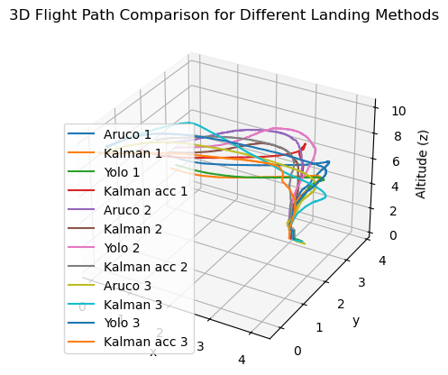

```python
fig = plt.figure()
ax = fig.add_subplot(111, projection='3d')
for i in range(len(x_data)):
    ax.plot(x_data[i], y_data[i], z_data[i], label=methods[i])
ax.set_xlabel('x')
ax.set_ylabel('y')
ax.set_zlabel('Altitude (z)')
plt.title('3D Flight Path Comparison for Different Landing Methods')
plt.legend()
plt.show()
```

## 3. 분류 모델 (딥러닝)

### 데이터 준비

X에는 각 데이터 포인트의 x, y, z, cp_x, cp_y 값을 포함하여 특성을 구성하고, y에는 착륙 방법을 저장한다. 이후 LabelEncoder를 사용하여 착륙 방법을 숫자로 인코딩한다.

```python
import numpy as np
from sklearn.model_selection import train_test_split
from sklearn.preprocessing import LabelEncoder
import tensorflow as tf

X = []  # 특징
y = []  # 레이블 (착륙 방법)

for i in range(len(x_data)):
    X.extend(np.column_stack((x_data[i], y_data[i], z_data[i], cp_x_data[i], cp_y_data[i])))
    y.extend([methods[i]] * len(x_data[i]))

# 특성과 레이블을 numpy 배열로 변환
X = np.array(X)
y = np.array(y)

# 레이블을 숫자로 인코딩
le = LabelEncoder()
y = le.fit_transform(y)
```

### 분류 모델 정의 및 학습

여기서는 심층 신경망(Deep Neural Network, DNN) 을 사용하여 착륙 방법을 분류한다. 모델에는 입력층 다음으로 relu 활성화 함수를 사용하는 두 개의 은닉층과 softmax 활성화 함수를 사용하는 출력층이 있다. adam 옵티마이저와 sparse_categorical_crossentropy 손실 함수를 사용하여 모델을 컴파일한다.

```python
X_train, X_test, y_train, y_test = train_test_split(X, y, test_size=0.2, random_state=42)

model = tf.keras.models.Sequential([
    tf.keras.layers.Dense(64, activation='relu', input_shape=(X_train.shape[1],)),
    tf.keras.layers.Dense(32, activation='relu'),
    tf.keras.layers.Dense(len(np.unique(y)), activation='softmax')
])

model.compile(optimizer='adam', loss='sparse_categorical_crossentropy', metrics=['accuracy'])

history = model.fit(X_train, y_train, epochs=30, batch_size=32, validation_split=0.2)
```

```
422/422 ━━━━━━━━━━━━━━━━━━━━ 2s 1ms/step - accuracy: 0.2822 - loss: 2.2553 - val_accuracy: 0.4665 - val_loss: 1.5824
422/422 ━━━━━━━━━━━━━━━━━━━━ 0s 1ms/step - accuracy: 0.4704 - loss: 1.5391 - val_accuracy: 0.5243 - val_loss: 1.3998
422/422 ━━━━━━━━━━━━━━━━━━━━ 1s 3ms/step - accuracy: 0.5363 - loss: 1.3689 - val_accuracy: 0.5569 - val_loss: 1.3212
422/422 ━━━━━━━━━━━━━━━━━━━━ 1s 2ms/step - accuracy: 0.6009 - loss: 1.2432 - val_accuracy: 0.6157 - val_loss: 1.1673
422/422 ━━━━━━━━━━━━━━━━━━━━ 1s 2ms/step - accuracy: 0.6333 - loss: 1.1609 - val_accuracy: 0.6916 - val_loss: 1.0510
422/422 ━━━━━━━━━━━━━━━━━━━━ 1s 2ms/step - accuracy: 0.6815 - loss: 1.0265 - val_accuracy: 0.7085 - val_loss: 0.9959
422/422 ━━━━━━━━━━━━━━━━━━━━ 1s 2ms/step - accuracy: 0.7080 - loss: 0.9822 - val_accuracy: 0.7239 - val_loss: 0.9417
422/422 ━━━━━━━━━━━━━━━━━━━━ 1s 2ms/step - accuracy: 0.7214 - loss: 0.9373 - val_accuracy: 0.7604 - val_loss: 0.8808
422/422 ━━━━━━━━━━━━━━━━━━━━ 1s 2ms/step - accuracy: 0.7474 - loss: 0.8719 - val_accuracy: 0.7595 - val_loss: 0.8385
422/422 ━━━━━━━━━━━━━━━━━━━━ 1s 2ms/step - accuracy: 0.7515 - loss: 0.8590 - val_accuracy: 0.7536 - val_loss: 0.8295
422/422 ━━━━━━━━━━━━━━━━━━━━ 1s 2ms/step - accuracy: 0.7746 - loss: 0.8004 - val_accuracy: 0.7660 - val_loss: 0.8143
422/422 ━━━━━━━━━━━━━━━━━━━━ 1s 2ms/step - accuracy: 0.7735 - loss: 0.7877 - val_accuracy: 0.7728 - val_loss: 0.7874
422/422 ━━━━━━━━━━━━━━━━━━━━ 1s 2ms/step - accuracy: 0.7846 - loss: 0.7362 - val_accuracy: 0.7722 - val_loss: 0.7956
422/422 ━━━━━━━━━━━━━━━━━━━━ 1s 2ms/step - accuracy: 0.7864 - loss: 0.7541 - val_accuracy: 0.7811 - val_loss: 0.7215
422/422 ━━━━━━━━━━━━━━━━━━━━ 1s 2ms/step - accuracy: 0.8025 - loss: 0.6764 - val_accuracy: 0.7933 - val_loss: 0.7167
422/422 ━━━━━━━━━━━━━━━━━━━━ 1s 2ms/step - accuracy: 0.8036 - loss: 0.6822 - val_accuracy: 0.8132 - val_loss: 0.6759
422/422 ━━━━━━━━━━━━━━━━━━━━ 1s 2ms/step - accuracy: 0.8105 - loss: 0.6640 - val_accuracy: 0.8060 - val_loss: 0.6831
422/422 ━━━━━━━━━━━━━━━━━━━━ 1s 2ms/step - accuracy: 0.8080 - loss: 0.6467 - val_accuracy: 0.8176 - val_loss: 0.6642
422/422 ━━━━━━━━━━━━━━━━━━━━ 1s 2ms/step - accuracy: 0.8210 - loss: 0.6291 - val_accuracy: 0.8152 - val_loss: 0.6602
422/422 ━━━━━━━━━━━━━━━━━━━━ 1s 2ms/step - accuracy: 0.8220 - loss: 0.6173 - val_accuracy: 0.8001 - val_loss: 0.6681
422/422 ━━━━━━━━━━━━━━━━━━━━ 1s 2ms/step - accuracy: 0.8255 - loss: 0.5848 - val_accuracy: 0.8321 - val_loss: 0.6114
422/422 ━━━━━━━━━━━━━━━━━━━━ 1s 2ms/step - accuracy: 0.8265 - loss: 0.5984 - val_accuracy: 0.8301 - val_loss: 0.6172
422/422 ━━━━━━━━━━━━━━━━━━━━ 1s 2ms/step - accuracy: 0.8245 - loss: 0.6074 - val_accuracy: 0.8093 - val_loss: 0.6316
422/422 ━━━━━━━━━━━━━━━━━━━━ 1s 2ms/step - accuracy: 0.8315 - loss: 0.5732 - val_accuracy: 0.8173 - val_loss: 0.6047
422/422 ━━━━━━━━━━━━━━━━━━━━ 1s 2ms/step - accuracy: 0.8384 - loss: 0.5609 - val_accuracy: 0.8384 - val_loss: 0.5845
422/422 ━━━━━━━━━━━━━━━━━━━━ 1s 2ms/step - accuracy: 0.8428 - loss: 0.5354 - val_accuracy: 0.8043 - val_loss: 0.6473
422/422 ━━━━━━━━━━━━━━━━━━━━ 1s 2ms/step - accuracy: 0.8345 - loss: 0.5551 - val_accuracy: 0.8321 - val_loss: 0.6059
422/422 ━━━━━━━━━━━━━━━━━━━━ 1s 2ms/step - accuracy: 0.8396 - loss: 0.5474 - val_accuracy: 0.8292 - val_loss: 0.5832
422/422 ━━━━━━━━━━━━━━━━━━━━ 1s 2ms/step - accuracy: 0.8485 - loss: 0.5186 - val_accuracy: 0.8413 - val_loss: 0.5821
422/422 ━━━━━━━━━━━━━━━━━━━━ 1s 2ms/step - accuracy: 0.8447 - loss: 0.5175 - val_accuracy: 0.8458 - val_loss: 0.5516
```

### 모델 평가 및 예측

테스트 데이터를 사용하여 모델의 정확도를 평가한 후, 테스트 샘플을 통해 착륙 방법을 예측한다.

```python
test_loss, test_acc = model.evaluate(X_test, y_test)
print(f'Test accuracy: {test_acc:.4f}')
sample = X_test[0].reshape(1, -1)
prediction = model.predict(sample)
predicted_label = le.inverse_transform([np.argmax(prediction)])
print(f'Predicted label: {predicted_label[0]}')
```

```
132/132 ━━━━━━━━━━━━━━━━━━━━ 0s 1ms/step - accuracy: 0.8483 - loss: 0.5972
Test accuracy: 0.8598
1/1 ━━━━━━━━━━━━━━━━━━━━ 0s 90ms/step
Predicted label: Yolo 2
```

## 4. 회귀 모델 (딥러닝)

### 정확도 데이터 생성

각 착륙 방법에 대해 목표 지점(원점)으로부터의 거리(정확도)를 계산하여 accuracy_data에 저장한다.

```python
accuracy_data = []

for i in range(len(cp_x_data)):
    distance = np.sqrt(np.array(cp_x_data[i])**2 + np.array(cp_y_data[i])**2)
    accuracy_data.extend(distance)

X = np.array(X)  # 경로 데이터 (특성)
y = np.array(accuracy_data)  # 정확도 (거리) 레이블
```

### 회귀 모델 정의 및 학습

회귀 모델은 착륙 위치의 정확도를 예측하는데 사용된다. 은닉층은 relu 활성화 함수를 사용하고, 출력층은 목표 지점과의 거리를 나타내는 단일 값을 예측한다. 손실 함수로 mean_squared_error를 사용하여 회귀 문제에 맞게 모델을 컴파일한다.

```python
X_train, X_test, y_train, y_test = train_test_split(X, y, test_size=0.2, random_state=42)

model = tf.keras.models.Sequential([
    tf.keras.layers.Dense(64, activation='relu', input_shape=(X_train.shape[1],)),
    tf.keras.layers.Dense(32, activation='relu'),
    tf.keras.layers.Dense(1)  # 거리 예측을 위한 출력층
])

model.compile(optimizer='adam', loss='mean_squared_error')

history = model.fit(X_train, y_train, epochs=30, batch_size=32, validation_split=0.2)
```

```
422/422 ━━━━━━━━━━━━━━━━━━━━ 3s 3ms/step - loss: 94.5993 - val_loss: 0.2876
422/422 ━━━━━━━━━━━━━━━━━━━━ 1s 2ms/step - loss: 0.2166 - val_loss: 0.1924
422/422 ━━━━━━━━━━━━━━━━━━━━ 1s 2ms/step - loss: 0.0944 - val_loss: 0.0556
422/422 ━━━━━━━━━━━━━━━━━━━━ 1s 2ms/step - loss: 0.0451 - val_loss: 0.6728
422/422 ━━━━━━━━━━━━━━━━━━━━ 1s 2ms/step - loss: 0.1253 - val_loss: 0.0361
422/422 ━━━━━━━━━━━━━━━━━━━━ 1s 2ms/step - loss: 0.0253 - val_loss: 0.0186
422/422 ━━━━━━━━━━━━━━━━━━━━ 1s 2ms/step - loss: 0.0187 - val_loss: 0.0315
422/422 ━━━━━━━━━━━━━━━━━━━━ 1s 2ms/step - loss: 0.0241 - val_loss: 0.0114
422/422 ━━━━━━━━━━━━━━━━━━━━ 1s 1ms/step - loss: 0.0119 - val_loss: 0.0174
422/422 ━━━━━━━━━━━━━━━━━━━━ 1s 2ms/step - loss: 0.0117 - val_loss: 0.0195
422/422 ━━━━━━━━━━━━━━━━━━━━ 1s 2ms/step - loss: 0.0218 - val_loss: 0.0293
422/422 ━━━━━━━━━━━━━━━━━━━━ 1s 2ms/step - loss: 0.0330 - val_loss: 0.0062
422/422 ━━━━━━━━━━━━━━━━━━━━ 1s 2ms/step - loss: 0.0154 - val_loss: 0.0096
422/422 ━━━━━━━━━━━━━━━━━━━━ 1s 2ms/step - loss: 0.0178 - val_loss: 0.0088
422/422 ━━━━━━━━━━━━━━━━━━━━ 1s 2ms/step - loss: 0.0296 - val_loss: 0.0057
422/422 ━━━━━━━━━━━━━━━━━━━━ 1s 2ms/step - loss: 0.0070 - val_loss: 0.3118
422/422 ━━━━━━━━━━━━━━━━━━━━ 1s 2ms/step - loss: 0.1843 - val_loss: 0.0086
422/422 ━━━━━━━━━━━━━━━━━━━━ 1s 2ms/step - loss: 0.2706 - val_loss: 0.0067
422/422 ━━━━━━━━━━━━━━━━━━━━ 1s 2ms/step - loss: 0.0413 - val_loss: 0.1010
422/422 ━━━━━━━━━━━━━━━━━━━━ 1s 2ms/step - loss: 0.0575 - val_loss: 0.0135
422/422 ━━━━━━━━━━━━━━━━━━━━ 1s 2ms/step - loss: 0.0092 - val_loss: 0.0039
422/422 ━━━━━━━━━━━━━━━━━━━━ 1s 2ms/step - loss: 0.0047 - val_loss: 0.0036
422/422 ━━━━━━━━━━━━━━━━━━━━ 1s 2ms/step - loss: 0.0162 - val_loss: 0.0030
422/422 ━━━━━━━━━━━━━━━━━━━━ 1s 2ms/step - loss: 0.0076 - val_loss: 0.0075
422/422 ━━━━━━━━━━━━━━━━━━━━ 1s 2ms/step - loss: 0.0281 - val_loss: 0.0053
422/422 ━━━━━━━━━━━━━━━━━━━━ 1s 2ms/step - loss: 0.0286 - val_loss: 0.0067
422/422 ━━━━━━━━━━━━━━━━━━━━ 1s 2ms/step - loss: 0.0668 - val_loss: 0.0244
422/422 ━━━━━━━━━━━━━━━━━━━━ 1s 2ms/step - loss: 0.0198 - val_loss: 0.0050
422/422 ━━━━━━━━━━━━━━━━━━━━ 1s 2ms/step - loss: 0.0036 - val_loss: 0.0056
422/422 ━━━━━━━━━━━━━━━━━━━━ 1s 2ms/step - loss: 0.0178 - val_loss: 0.0029
```

### 정확도 예측 및 시각화

테스트 샘플을 사용하여 예측된 정확도를 확인하고, 착륙 시점의 정확도를 시각화하여 각 방법의 착륙 정확도를 시간에 따라 비교한다.

```
1/1 ━━━━━━━━━━━━━━━━━━━━ 0s 50ms/step
```

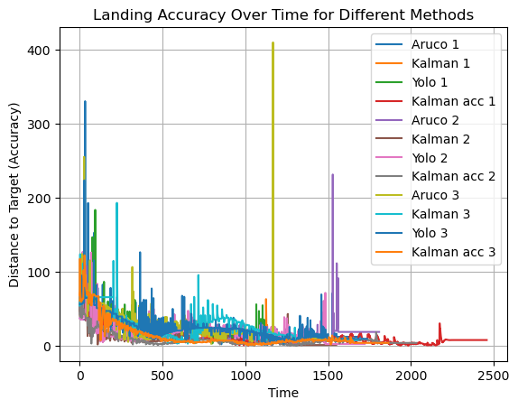

```python
sample = X_test[0].reshape(1, -1)
predicted_accuracy = model.predict(sample)

plt.figure()
for i in range(len(cp_x_data)):
    distance = np.sqrt(np.array(cp_x_data[i])**2 + np.array(cp_y_data[i])**2)
    plt.plot(distance, label=methods[i])
plt.xlabel('Time')
plt.ylabel('Distance to Target (Accuracy)')
plt.title('Landing Accuracy Over Time for Different Methods')
plt.legend()
plt.grid(True)
plt.show()
```